# Manipulando palavras com stringr

Fellipe

12 de dezembro de 2017

# Manipulação de strings e Text mining

Estudamos números e mais números na graduação de estatística (não sei nem se ainda consigo enxergar algarismos gregos como letras) e mesmo assim um problema frequente na vida de quem trabalha com dados é a manipulação de variáveis do tipo *string*.

Uma variável do tipo *string* é uma variável do tipo texto e esse tipo de objeto costuma causar alguns problemas na análise de dados se não forem devidamente tratados.

Desde modificações em nomes de colunas em data.frames até as mais espertas aplicações de text mining com corpus, a limpeza e manipulação de strings é quase sempre necessária

# Criando nossas funções

Antes de apresentar alguns pacotes com funções úteis para manipular strings, gostaria de comentar que pode ser bem útil desenvolvermos funções para nosso próprio uso, não é raro realizarmos o mesmo procedimento em diferentes etapas das análises, o que pode tornar o código desorganizado ou poluído com tantas linhas repetidas.

Trago aqui de exemplo uma função que encontrei recentemente para remover acentos no [stackoverflow](https://pt.stackoverflow.com/questions/46473/remover-acentos) que já me ajudou bastante, veja a função:

```r
rm_accent <- function(str,pattern="all") {
  # Rotinas e funções úteis V 1.0
  # rm.accent - REMOVE ACENTOS DE PALAVRAS
  # Função que tira todos os acentos e pontuações de um vetor de strings.
  # Parâmetros:
  # str - vetor de strings que terão seus acentos retirados.
  # patterns - vetor de strings com um ou mais elementos indicando quais acentos deverão ser retirados.
  #            Para indicar quais acentos deverão ser retirados, um vetor com os símbolos deverão ser passados.
  #            Exemplo: pattern = c("´", "^") retirará os acentos agudos e circunflexos apenas.
  #            Outras palavras aceitas: "all" (retira todos os acentos, que são "´", "`", "^", "~", "¨", "ç")
  if(!is.character(str))
    str <- as.character(str)

  pattern <- unique(pattern)

  if(any(pattern=="Ç"))
    pattern[pattern=="Ç"] <- "ç"

  symbols <- c(
    acute = "áéíóúÁÉÍÓÚýÝ",
    grave = "àèìòùÀÈÌÒÙ",
    circunflex = "âêîôûÂÊÎÔÛ",
    tilde = "ãõÃÕñÑ",
    umlaut = "äëïöüÄËÏÖÜÿ",
    cedil = "çÇ"
  )

  nudeSymbols <- c(
    acute = "aeiouAEIOUyY",
    grave = "aeiouAEIOU",
    circunflex = "aeiouAEIOU",
    tilde = "aoAOnN",
    umlaut = "aeiouAEIOUy",
    cedil = "cC"
  )

  accentTypes <- c("´","`","^","~","¨","ç")

  if(any(c("all","al","a","todos","t","to","tod","todo")%in%pattern)) # opcao retirar todos
    return(chartr(paste(symbols, collapse=""), paste(nudeSymbols, collapse=""), str))

  for(i in which(accentTypes%in%pattern))
    str <- chartr(symbols[i],nudeSymbols[i], str)

  return(str)
}
```

Criar nossas próprias funções é muito simples em R e eu encorajo a todos a começarem a trabalhar com funções próprias também (além das nativas do R), pois o programa fica muito mais dinâmico e limpo.

# O pacote `stringr`

Além do pacote `dplyr`, mais uma vez [Hadley Wickham](https://github.com/hadley) trás uma solução bastante útil para facilitar nossa vida de programador estatístico (ou cientista de dados se preferir, seguindo as “tendências da moda” de “data scientist”) com o pacote `stringr`, que possui uma sintaxe consistente, permitindo a manipulação de textos com muito mais facilidade.

Seu uso consiste em uma variedade de utilidades que podem ser consultadas diretamente de dentro do R ao escrever `str_` (após carregar o pacote) e aguardar um instante que a seguinte lista de funções será exibida:

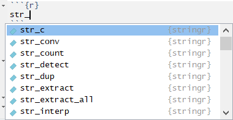

Note que essa aplicação funciona para qualquer pacote do R

Portanto, inicialmente vamos carregar o pacote:

```r
library(stringr)
```

Com o pacote carregado já podemos fazer o uso de algumas das funções que são bem úteis.

## Arrumando titulos de base de dados

É muito comum que os cabeçalhos de uma base de dados venha repleta de caracteres especiais como este exemplo:

```r
nomes=c('Sexo', 'Aniversário', 'Situação', 'Raça', 'Peso', 'Altura', 'IMC', 'Tipo físico', 'Tabagismo', 'tabaco por dia (cig/dia)', 'Alcool (dose/semana)', 'Drogas/g', 'Café/dia', 'Suco/dia', 'Obesidade', 'Magro');nomes
```

```
##  [1] "Sexo"                     "Aniversário"
##  [3] "Situação"                 "Raça"
##  [5] "Peso"                     "Altura"
##  [7] "IMC"                      "Tipo físico"
##  [9] "Tabagismo"                "tabaco por dia (cig/dia)"
## [11] "Alcool (dose/semana)"     "Drogas/g"
## [13] "Café/dia"                 "Suco/dia"
## [15] "Obesidade"                "Magro"
```

Unindo as funções deste pacote com a sintaxe do pacote `dplyr` podemos elaborar uma função que irá facilitar bastante nas chamadas das colunas do data.frame na hora da análise, veja:

```r
ajustar_nomes=function(x){
 x%>%
  stringr::str_trim() %>%
  stringr::str_to_lower() %>%
  rm_accent() %>%
  stringr::str_replace_all("[/' '.()]", "_") %>%
  stringr::str_replace_all("_+", "_") %>%
  stringr::str_replace("_$", "")
}
nomes=ajustar_nomes(nomes)
nomes
```

```
##  [1] "sexo"                   "aniversario"
##  [3] "situacao"               "raca"
##  [5] "peso"                   "altura"
##  [7] "imc"                    "tipo_fisico"
##  [9] "tabagismo"              "tabaco_por_dia_cig_dia"
## [11] "alcool_dose_semana"     "drogas_g"
## [13] "cafe_dia"               "suco_dia"
## [15] "obesidade"              "magro"
```

### Função str_replace() e str_replace_all()

Esse é o tipo de função que é utilizada com frequência. Utilizada para substituir ou remover uma (ou todas) as ocorrências de determinado carácter no objeto, suponha a seguinte situação:

```r
exemplo <- c("o esperto", "o doido", "o normal")
```

Para remover a primeira vogal de cada string:

```r
str_replace(exemplo, "[aeiou]", "")
```

```
## [1] " esperto" " doido"   " normal"
```

Para substitui todas as vogais por “_"

```r
str_replace_all(exemplo, "[aeiou]", "_")
```

```
## [1] "_ _sp_rt_" "_ d__d_"   "_ n_rm_l"
```

Considere este novo exemplo:

```r
exemplo2 <- "O-    ffffzx2, faifavuvuifoovvv fovvo"
```

Para substitui o primeiro f (ou f’s) por “v”:

```r
exemplo2 <- str_replace(exemplo2, "f+", "v")
exemplo2
```

```
## [1] "O-    vzx2, faifavuvuifoovvv fovvo"
```

Para substituir todos os v’s (em sequência ou não) por “c”:

```r
exemplo2 <- str_replace_all(exemplo2, "v+", "c")
exemplo2
```

```
## [1] "O-    czx2, faifacucuifooc foco"
```

Substituir todos os f por i:

```r
exemplo2 <- str_replace_all(exemplo2, "f", "i")
exemplo2
```

```
## [1] "O-    czx2, iaiiacucuiiooc ioco"
```

### Função str_split() e str_split_fixed()

Essas funções separam uma string em várias de acordo com um separador.

```r
frase <- 'Analisar palavras é muito legal. Apesar de todos os desafios as informações que podemos extrair podem revelar informações incrívelmente úteis. Esse exemplo esta sendo escrito pois vamos retirar cada frase desse paragrafo separadamente.'

str_split(frase, fixed('.'))
```

```
## [[1]]
## [1] "Analisar palavras é muito legal"
## [2] " Apesar de todos os desafios as informações que podemos extrair podem revelar informações incrívelmente úteis"
## [3] " Esse exemplo esta sendo escrito pois vamos retirar cada frase desse paragrafo separadamente"
## [4] ""
```

### Função `str_sub()`

Para obter uma parte fixa de uma string podemos utilizar o comando `str_sub()` da seguinte maneira:

```r
#Suponha as seguintes palavras:
words=c("00-casados", "01-casamento", "02-emprego", "03-empregado")
```

Selecionado apenas do quarto até o último caracteres da string:

```r
str_sub(words, start = 4) # começa no 4 caractere
```

```
## [1] "casados"   "casamento" "emprego"   "empregado"
```

Selecionando apenas os dois primeiros caracteres da string:

```r
str_sub(words, end = 2) # termina no 2 caractere
```

```
## [1] "00" "01" "02" "03"
```

Para obter caracteres utilizando o sinal de negação `-`

```r
#Suponha:
words <- c("casamento-01", "emprego-02", "empregado-03")
str_sub(words, end = -4)   #Seleciona todos os valores menos os últimos 3
```

```
## [1] "casamento" "emprego"   "empregado"
```

```r
str_sub(words, start = -2) #Seleciona todos os valores até o segundo valor
```

```
## [1] "01" "02" "03"
```

Também é possível utilizar os argumentos `end` e `start` conjuntamente, veja

```r
#É possível usar os argumentos start e end conjuntamente.
words <- c("__casamento__", "__emprego__", "__empregado__")
str_sub(words, start=3, end=-3)
```

```
## [1] "casamento" "emprego"   "empregado"
```

A manipulação de strigs é uma tarefa bem trabalhosa e algumas vezes até complexa, caso precise de mais alguma referência das possíveis funções, encontrei um material no curso-r muito bom tratando sobre este tema.

# Pacote `tm`

O pacote `tm` é um clássico para o text mining em R, quando os dados se apresentam de forma não estrutura, necessitam de uma preparação prévia que pode ser considerada um tipo de pré-processamento.

Inicialmente, carregando o pacote:

```r
suppressMessages( library(tm))
```

Em bases de dados textuais, conhecidos como *corpus* ou *corpora* são tratado como “documentos” e cada “documento” em um *corpus* pode assumir diferentes características em relação ao tamanho do texto (sequências de caracteres), tipo de conteúdo (assunto abordado), língua na qual é escrito ou tipo de linguagem adotada dentro outros exemplos.

A transformação de um *corpus* em um conjunto de dados que possa ser submetido à procedimentos de análise consiste em um processo que gera uma representação capaz de descrever cada documento em termos de suas características.

Para criar um *corpus* a partir de um `data.frame` basta utilizar o seguinte comando:

```r
#Criando o corpus para o tratamento das variaveis com pacote library(tm):
corpus <- Corpus(DataframeSource(data.frame(x)))
```

A seguir veremos algumas dos possíveis procedimentos para a manipulação de dados em um *corpus*.

## Limpeza de um corpus

Uma sequência de comando interessantes para a limpeza de um *corpus* que já utilizei bastante é a seguinte:

```r
#Realizando a limpeza da base de dados:
#Acrescentar mais stopwords para retirada;
#novas=c()

#Tratamento do corpus
tratar_corpus=function(x){
x%>%
  tm_map(stripWhitespace)%>%                                #remover excessos de espaços em branco
  tm_map(removePunctuation)%>%                              #remover pontuacao
  tm_map(removeNumbers)%>%                                  #remover numeros
  tm_map(removeWords, c(stopwords("portuguese"),novas))%>%  #remmover as stopwords,crie um vetor chamado "novas" para incluir novas stopwords
  tm_map(stripWhitespace)%>%                                #remover excessos de espaços em branco novamente
  tm_map(removeNumbers)%>%                                  #remover numeros novamente
  tm_map(content_transformer(tolower))%>%                   #colocar todos caracteres como minusculo
  tm_map(stemDocument)                                      #Extraindo os radicais
}
corpus=tratar_corpus(corpus)
#inspect(corpus[[3]]) 3Leitura de algum documento específico
```

Para criar a matriz de termos podemos utilizar o comando:

```r
#Criando a matrix de termos:
corpus_tf=TermDocumentMatrix(corpus, control = list(minWordLength=2,minDocFreq=5))
```

Caso precise trabalhar com a transformação `tf-idf` basta utilizar:

```r
#Caso precise utilizar a medida tf-idf em um corpus:
corpus_tf_idf=weightTfIdf(corpus_tf,normalize=T)
```

## Obtendo uma matriz de frquências a partir de um corpos

Criando uma matriz para facilitar a manipulação dos dados

```r
#Transformando em matrix para permitir a manipulação:
matriz = as.matrix(corpus_tf)

#organizar os dados de forma decrescente
matriz = sort(rowSums(matriz), decreasing=T)

#criando um data.frame para a matriz
matriz = data.frame(word=names(matriz), freq = matriz)
```

Caso seja necessário conferir visualmente as palavras mais mencionadas, também podemos utilizar gráficos, como por exemplo:

```r
#Vejamos os primeiros 10 registros:
head(matriz, n=10)
```

```
##              word freq
## ano           ano  296
## pra           pra  226
## site         site  156
## todo         todo  144
## cadastro cadastro  134
## faz           faz  124
## fazer       fazer  124
## inss         inss  120
## dia           dia  114
## receb       receb  114
```

[figure not shown]

```r
#Vejamos visualmente:
head(matriz, n=10) %>%
  ggplot(aes(word, freq)) +
  geom_bar(stat = "identity", color = "black", fill = "#87CEFA") +
  geom_text(aes(hjust = 1.3, label = freq)) +
  coord_flip() +
  labs(title = "20 Palavras mais mensionadas",  x = "Palavras", y = "Número de usos")
```